# Test for overall randomness of plankton distribution

Author

Thelma Panaïotis

**Warning**

Work with a subsample of the data: 10^{4} images.

```r
## Subsampling
if (sub_sample){
  load("data/00.subsample.Rdata")
  images <- images_sub
  plankton <- plankton_sub
} else {
  ## All data
  images <- read_parquet("data/00.images_clean.parquet")
  plankton <- read_parquet("data/00.plankton_clean.parquet")
}

# list img names
img_names <- sort(unique(images$img_name))

## Null hypothesis data
load(here("data/01.null_data.Rdata"))
```

Define window size for point pattern analysis.

```r
# image volume in pixels
vol <- c()
vol$x <- 10240
vol$y <- 2048
vol$z <- 9572
```

## Distances between all organisms

To investigate overall randomness, let’s compute distances between all pairs of organisms within an image.

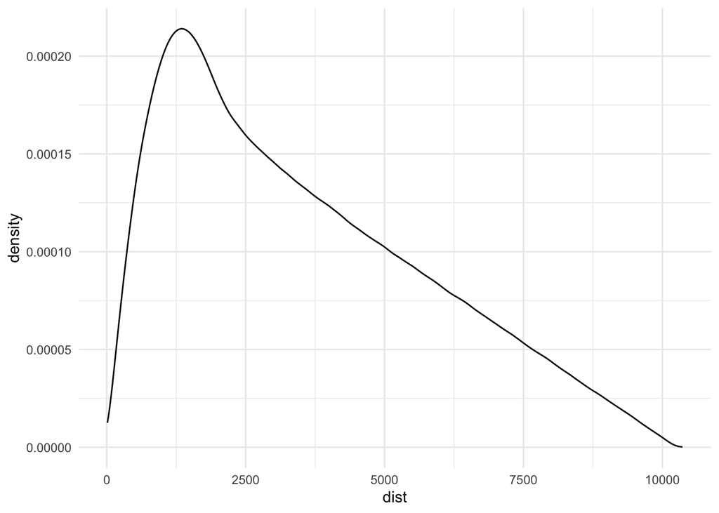

```r
# Loop over images and compute distances between all points within each image
dist_all <- compute_all_dist(plankton, n_cores = n_cores)

# Plot all
#ggplot(dist_all) +
#  geom_density(aes(x = dist, group = img_name), alpha = 0.1, linewidth = 0.02, colour = "dodgerblue") +
#  geom_density(aes(x = dist))

ggplot(dist_all) +
  geom_density(aes(x = dist))
```

## Compare with null data using Kuiper test

Plot ECDF for null distances and all data. Subsample to 10000 points for computations.

**Subsample to 10^{4} distances for computation.**

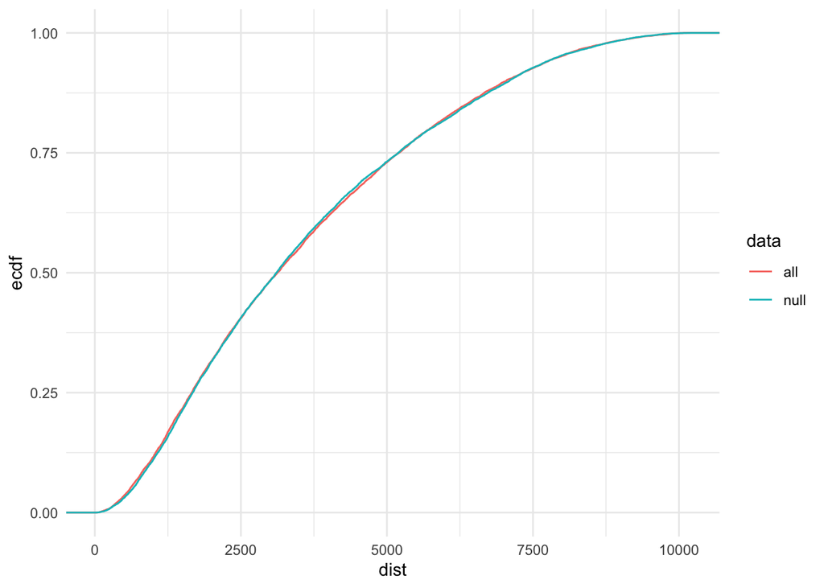

```r
df_dist <- bind_rows(
  dist_all %>% select(dist) %>% mutate(data = "all") %>% slice_sample(n = n_dist),
  dist_all_rand %>% select(dist) %>% mutate(data = "null") %>% slice_sample(n = n_dist)
)


df_dist %>%
  ggplot(aes(dist, colour = data)) +
  stat_ecdf(geom = "step")
```

This looks very similar…

Perform Kuiper test on a subsample

```r
s1 <-  df_dist %>% filter(data == "all") %>% pull(dist)
s2 <-  df_dist %>% filter(data == "null") %>% pull(dist)
out <-  kuiper_test(s1, s2)
out
```

```
Test Stat   P-Value
   0.0195    0.2915
```

```r
summary(out)
```

```
KUIPER Test
=========================
Test Statistic: 0.0195
       P-Value: 0.2915
- - - - - - - - - - - - -
     n1      n2 n.boots
  10000   10000    2000
=========================
Test stat rejection threshold for alpha = 0.05 is: 0.0246
Null not rejected: samples may be from same distribution
```

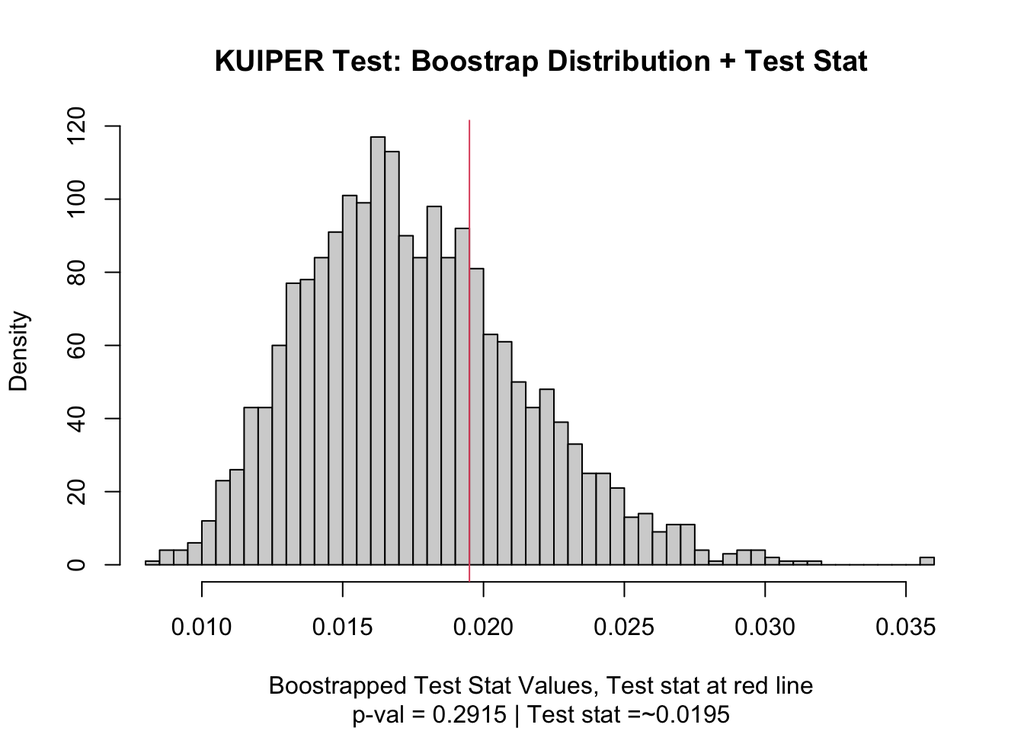

```r
plot(out)
```

… and indeed it is similar!

**Conclusion**

**Distances between planktonic organisms at the local scale do not differ from the distances that could be expected if plankton was randomly distributed.**

This is quite unexpected, let’s perform an additional test to confirm (or infirm) this.

## Complete spatial randomness test based on quadrats

Let’s perform a test of complete spatial randomness (CSR) based on quadrat counts for each image.

```r
# 1 image = 5 square frames
# we can do 10 quadrats in x and 2 in y: square quadraits, 20 per image
nx <- 10 # quadrats in x dimension
ny <- 2  # quadrats in y dimension

# p-value threshold for randomness
thres <- 0.01

# Loop over images and perform the quadrat test in each one
qt_all <- mclapply(img_names, function(name) {
  # Get points within image
  points <- plankton %>%
    filter(img_name == name) %>%
    select(x, y)

  # Convert to ppp
  points_ppp <- ppp(points$x, points$y, window = owin(xrange = c(1, vol$x), yrange = c(1, vol$y)))

  # Perform quadrat test and extract p-value
  qt <- quadrat.test(points_ppp, nx = nx, ny = ny, method = "MonteCarlo", conditional = TRUE)

  # Store results in a tibble and return it
  tibble(img_name = name, n_obj = nrow(points), p_value = qt$p.value)
}, mc.cores = n_cores)

# Transform list to one tibble
df_qt <- do.call(bind_rows, qt_all) %>%
  # distribution is random if p_value > thres
  mutate(random = ifelse(p_value < thres, FALSE, TRUE))
summary(df_qt)
```

```
   img_name             n_obj          p_value        random
 Length:10000       Min.   :  2.0   Min.   :0.001   Mode :logical
 Class :character   1st Qu.: 11.0   1st Qu.:0.275   FALSE:85
 Mode  :character   Median : 20.0   Median :0.525   TRUE :9915
                    Mean   : 28.9   Mean   :0.518
                    3rd Qu.: 38.0   3rd Qu.:0.765
                    Max.   :424.0   Max.   :1.000
```

Positions of planktonic organisms are indeed random in most cases, and the few cases of non-randomness are caused by the p-value threshold that we used: 0.85% of non-randomness for a randomness threshold set at 1% .

Let’s plot the distribution of p-values and check that there is no relationship between p-value and the number of objects within the image.

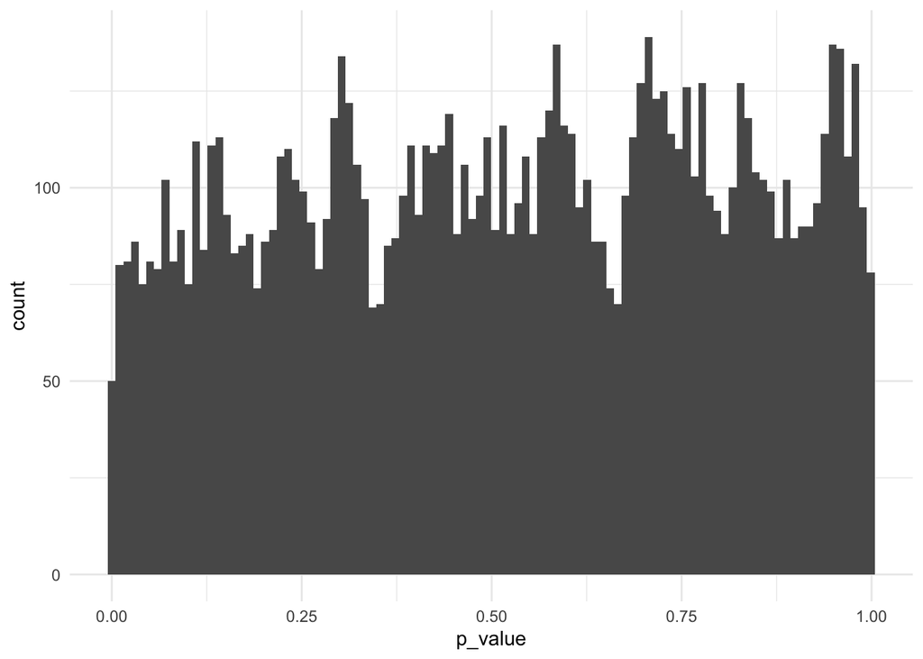

```r
ggplot(df_qt) + geom_histogram(aes(x = p_value), bins = 100)
```

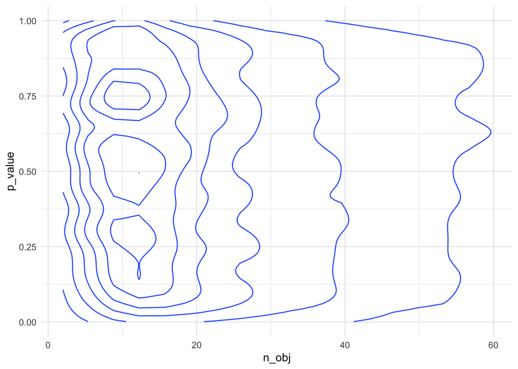

```r
ggplot(df_qt) + geom_density_2d(aes(x = n_obj, y = p_value))
```

All good!

**Conclusion**

**When considering all planktonic organisms regardless of their taxa, they are randomly distributed at the local scale.**